# Stringmol run analysis

# prelims

Set the `froot` variable to the path to the files for these tests:

```r
#froot="D:/sjh/stringmol/out3smsp/"
froot="~/Desktop/paulien/sm250r/out3/"
```

# Popdy

First thing we want is overall pop size in a file. This function is in `14.04/home/sjh/Desktop/sjh/stringmol/R/plotpopdy.R`

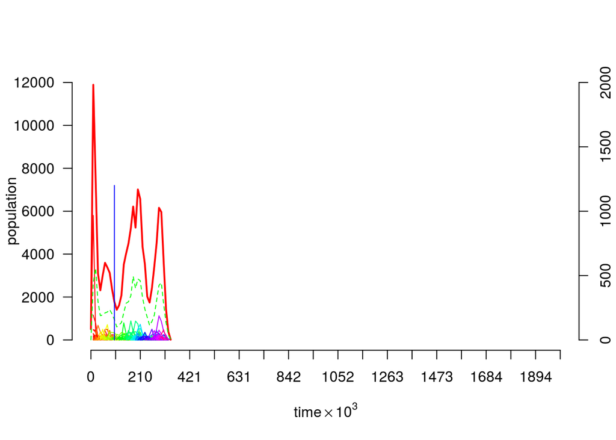

```r
source("../R/plot_onepop.R")

plot.onepop(sprintf("%spopdy001.dat",froot),"example1popdy.pdf",12,12,minpop=100, totpop=T,plotnspp = T)
segments(x0=100000,y0=0,y1=1200,col="blue")
```

the blue line indicates $t=100000$ - which is where the splist and out1 files explored below relate to.

Concerns: - this only records pop every 10000 timesteps - potentially many generations between recordings. Understandable though - if we find a particular feature, we can go back and rerun to get more detail. - Nothing here about species length - need to grab that info from the right spplists file - Need a sanity check on the species numbers via the spplists (since we are purging these).

# Community structure

## stats

### Stats from `splist` files

Theres a function called `splist_stats` that generates these - let’s check it out:

```r
source("../R/splist_stats.R")
sps <- splist_stats(sprintf("%ssplist100000.dat",froot),tmin=90000)
```

That works, so let’s see if we can do an iteration:

```r
gotdata<- T
tt <- 10000
while(gotdata){
  fn <- sprintf("%ssplist%d.dat",froot,tt)
  if(file.exists(fn)){
    message(sprintf("\nProcessing Time %d:",tt))
    splist_stats(fn,tmin=(tt-10000))
  }
  else
    gotdata <- F

  tt = tt+10000
}
```

```
##
## Processing Time 10000:
```

```
##
## Processing Time 20000:
```

```
##
## Processing Time 30000:
```

```
##
## Processing Time 40000:
```

```
##
## Processing Time 50000:
```

```
##
## Processing Time 60000:
```

```
##
## Processing Time 70000:
```

```
##
## Processing Time 80000:
```

```
##
## Processing Time 90000:
```

```
##
## Processing Time 100000:
```

```
##
## Processing Time 110000:
```

```
##
## Processing Time 120000:
```

```
##
## Processing Time 130000:
```

```
##
## Processing Time 140000:
```

```
##
## Processing Time 150000:
```

```
##
## Processing Time 160000:
```

```
##
## Processing Time 170000:
```

```
##
## Processing Time 180000:
```

```
##
## Processing Time 190000:
```

```
##
## Processing Time 200000:
```

```
##
## Processing Time 210000:
```

```
##
## Processing Time 220000:
```

```
##
## Processing Time 230000:
```

```
##
## Processing Time 240000:
```

```
##
## Processing Time 250000:
```

```
##
## Processing Time 260000:
```

```
##
## Processing Time 270000:
```

```
##
## Processing Time 280000:
```

```
##
## Processing Time 290000:
```

```
##
## Processing Time 300000:
```

```
##
## Processing Time 310000:
```

```
##
## Processing Time 320000:
```

```
##
## Processing Time 330000:
```

```
##
## Processing Time 340000:
```

That works as far as it goes, but we aren’t seeing the *dominant* reaction that we are looking for, just the “most common reaction that first occured withing 10000 time steps”.

### Stats from `.conf` files

If we want the commonest reaction at time x, we might be better to look at the out1*conf files - these are a snapshot of the current system by definition - these will take a little more work to interpret however, but they will be exact. We might even be able to use these to develop a network of what is going on…

Each entry for a reaction in the current state of the system looks like this:

```
%%% REACTION 718
REACTION
###############  8557 WWGEWLHHHRLUEUWJJJRNJXUUUDGRGJLRWWRE$BLUBO^B>C$=?>$$BLUBO%}OYHOB
REACTION_ACTIVE  8557 WWGEWLHHHRLUEUWJJJRNJXUUUDGRGJLRWWRE$BLUBO^B>C$=?>$$BLUBO%}OYHOBWWGEWLHHHRLUEUWJJJRNJXUUUDGRGJ irwf: 1 0 49 0 30 16 1 0 94 1 0 46 grid: 165 39  pass_index: 1629

PASSIVE
REACTION_PASSIVE 8557 WWGEWLHHHRLUEUWJJJRNJXUUUDGRGJLRWWRE$BLUBO^B>C$=?>$$BLUBO%}OYHOB grid: 166 40
###############  8557 WWGEWLHHHRLUEUWJJJRNJXUUUDGRGJLRWWRE$BLUBO^B>C$=?>$$BLUBO%}OYHOB

AGENT  JJRNJXUUUDGRHJLRWWRE$BLUBO^>C$=?>$$BUBOUB$=?>$$=?>$$BLUBO%}OYHOB 1 Q
GRIDPOS  190 30

AGENT  $BLUBO^>C$=?>$$BUBOUBO^B>C$=?>$$BLUBO%}OYHOB 1 Q
GRIDPOS  189 29
```

```r
require (stringr)
source("../R/splist_stats.R")

####Function 'arguments'
  fn <- sprintf("%sout1_100000.conf",froot)
  verbose <- T
  spldata <-  splist_stats(sprintf("%ssplist100000.dat",froot))

####Function 'body'

  cf <- read.table(fn,as.is = T, fill = T, sep="\n",comment.char="",stringsAsFactors = F)

  #get the row number of the start of each reaction entry
  rpos <- which(str_sub(cf[,1],1,12)=="%%% REACTION")

  nr <- length(rpos)
  actno <- vector(length = nr)
  actseq <- vector(length = nr)
  pasno <- vector(length = nr)
  passeq <- vector(length = nr)

  #build the data for each reaction - similar to the splist analysis
  for(rr in 1:nr){
    words <-strsplit(cf[rpos[rr]+2,1],split=" ")
    actno[rr] <- as.numeric(words[[1]][3])
    actseq[rr] <- words[[1]][4]
    words <-strsplit(cf[rpos[rr]+6,1],split=" ")
    pasno[rr] <- as.numeric(words[[1]][3])
    passeq[rr] <- words[[1]][4]
    #message(sprintf("Active  molecule %s seq %s",actno[rr],actseq[rr]))
    #message(sprintf("Passive molecule %s seq %s",actno[rr],actseq[rr]))
  }

  eachreaction<-data.frame(actno,actseq,pasno,passeq)

  reactions <- unique(eachreaction)
  reactions$type = "<unknown>"

  for(rr in 1:nrow(reactions)){
    ca <- eachreaction[eachreaction$actno == reactions$actno[rr] & eachreaction$pasno == reactions$pasno[rr],]
    reactions$count[rr] = nrow(ca)
  }
  reactions <- reactions[order(reactions$count,decreasing = T),]

  #Get the product molecule from the splist:
  for(rr in 1:nrow(reactions)){

    if(is.na(reactions$actno[rr]) || is.na(reactions$pasno[rr])){

        #message(sprintf("Reaction %d has NAs  (NA)",rr))
        reactions$type[rr]= "na"
        next
    }


    dd <- spldata[(spldata$act == reactions$actno[rr]) & (spldata$pass == reactions$pasno[rr]), ]
    if(nrow(dd)==0){
      #message(sprintf("Reaction %d has no product (NP)",rr))
      reactions$type[rr]= "NP"
    }
    if(reactions$actno[rr] == reactions$pasno[rr]){
      if(nrow(dd)==1){
        if(dd$spp == reactions$actno[rr]){
          #message(sprintf("Reaction %d is an exact self:self replicator (ER)*",rr))
          reactions$type[rr]= "ER"
        }
        else{
          #message(sprintf("Self:self reaction with different product (DP)*",rr))
          reactions$type[rr]= "DP"
        }
      }
      if(nrow(dd)>1){
        #message(sprintf("Reaction %d is a pathological replicator (PR)",rr))
        reactions$type[rr]= "PR"
      }
    }
    else{
      if(nrow(dd)==1){
        if(dd$spp == reactions$pasno[rr]){
          #message(sprintf("Reaction %d is parsitic (PA)*",rr))
        reactions$type[rr]= "PA"
        }
        else{
          #message(sprintf("non-self reaction with different product (DN)*",rr))
          reactions$type[rr]= "DN"
        }
      }
      if(nrow(dd)>1){
        #message(sprintf("Reaction %d is a pathological non-self replicator (PN)",rr))
        reactions$type[rr]= "PN"
      }
    }


  }
```

Check that we’ve now got this in a function:

```r
source("../R/splist_stats.R")
source("../R/rconf_stats.R")
source("../R/rconf_data.R")
reactions <- rconf_stats(fn = sprintf("%sout1_100000.conf",froot), spfn = sprintf("%ssplist100000.dat",froot))
```

Now we can count the different reaction types:

```r
rclass <- c("NA","NP","ER","DP","PR","PA","DN","PN")
rcounts <- data.frame(rclass)
for(rr in 1:length(rclass)){
  dd <- reactions[reactions$type == rclass[rr],]
  rcounts$count[rr] = nrow(dd)
}
```

That works, so let’s see if we can do an iteration:

```r
source("../R/splist_stats.R")
source("../R/rconf_stats.R")

gotdata<- T
tt <- 20000
#rcounts <- data.frame(rclass)
rcounts <- data.frame(time=0,"NA"=0,NP=0,ER=1,DP=0,PR=0,PA=0,DN=0,PN=0)
rsumcounts <- data.frame(time=0,"NA"=0,NP=0,ER=500,DP=0,PR=0,PA=0,DN=0,PN=0)
count <- vector(length = length(rclass))
scount <- vector(length = length(rclass))
count <- 0
sumcount <- 0
rno<-2

while(gotdata ){#&& tt < 320000){
  message(sprintf("Processing time %d",tt))
  fn <- sprintf("%ssplist%d.dat",froot,tt)
  spfn <- sprintf("%sout1_%d.dat",froot,tt)
  if(file.exists(fn)){
    message(sprintf("\nProcessing Time %d:",tt))
    reactions <- rconf_stats(fn = sprintf("%sout1_%d.conf",froot,tt), spfn = sprintf("%ssplist%d.dat",froot,tt))

    message("\n\nout\n\n")
    if(is.na(reactions)){
    }
    else{

      count <- 0
      sumcount <- 0

      for(rr in 1:length(rclass)){

        dd <- reactions[reactions$type == rclass[rr],]
        count[rr] <- nrow(dd)
        sumcount[rr] <- sum(dd$count)
      }
      #assign(sprintf("t%d",tt))

      trow = c(tt,t(count))
      rcounts <- rbind(rcounts,trow)

      trow = c(tt,t(sumcount))
      rsumcounts <- rbind(rsumcounts,trow)
      #colnames(rcounts)[rno] <- sprintf("t%d",tt)

      #rno <- rno + 1
    }

  }
  else{
    gotdata <- F
  }
  tt = tt+20000
}
```

```
## Processing time 20000
```

```
##
## Processing Time 20000:
```

```
##
##
## out
```

```
## Processing time 40000
```

```
##
## Processing Time 40000:
```

```
##
##
## out
```

```
## Processing time 60000
```

```
##
## Processing Time 60000:
```

```
##
##
## out
```

```
## Processing time 80000
```

```
##
## Processing Time 80000:
```

```
##
##
## out
```

```
## Processing time 100000
```

```
##
## Processing Time 100000:
```

```
##
##
## out
```

```
## Processing time 120000
```

```
##
## Processing Time 120000:
```

```
##
##
## out
```

```
## Processing time 140000
```

```
##
## Processing Time 140000:
```

```
##
##
## out
```

```
## Processing time 160000
```

```
##
## Processing Time 160000:
```

```
##
##
## out
```

```
## Processing time 180000
```

```
##
## Processing Time 180000:
```

```
##
##
## out
```

```
## Processing time 200000
```

```
##
## Processing Time 200000:
```

```
##
##
## out
```

```
## Processing time 220000
```

```
##
## Processing Time 220000:
```

```
##
##
## out
```

```
## Processing time 240000
```

```
##
## Processing Time 240000:
```

```
##
##
## out
```

```
## Processing time 260000
```

```
##
## Processing Time 260000:
```

```
##
##
## out
```

```
## Processing time 280000
```

```
##
## Processing Time 280000:
```

```
##
##
## out
```

```
## Processing time 300000
```

```
##
## Processing Time 300000:
```

```
##
##
## out
```

```
## Processing time 320000
```

```
##
## Processing Time 320000:
```

```
##
##
## out
```

```
## Processing time 340000
```

```
##
## Processing Time 340000:
```

```
##
##
## out
```

```
## Processing time 360000
```

```r
#Now we can plot the change in diversity:
#https://www.r-graph-gallery.com/stacked-barplot/
```

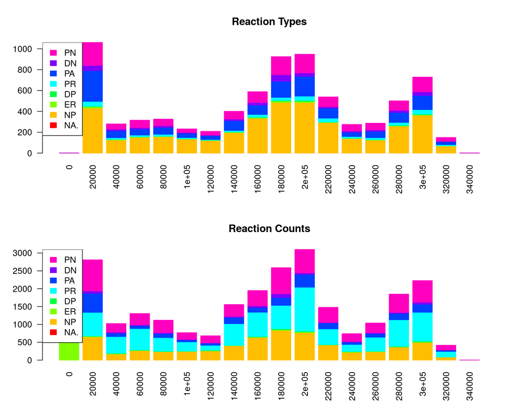

```r
bcols = rainbow(ncol(rcounts[2:9]))
par(mfrow=c(2,1))
barplot(t(rcounts[2:9]),col=bcols,border=bcols,names=rcounts[,1],las=2,main="Reaction Types")
cn <-colnames(rcounts)
legend("topleft",legend=rev(cn[2:9]),fill=rev(bcols),border=rev(bcols))

barplot(t(rsumcounts[2:9]),col=bcols,border=bcols,names=rcounts[,1],las=2,main="Reaction Counts")
cn <-colnames(rcounts)
legend("topleft",legend=rev(cn[2:9]),fill=rev(bcols),border=rev(bcols))
```

```r
#legend("topleft",legend=(cn[2:9]),fill=(bcols),border=(bcols))
```

## Handling the warnings…

let’s look at t=80000 again and make sure we are handling warnings properly.

```r
source("../R/splist_stats.R")
source("../R/rconf_data.R")
source("../R/rconf_stats.R")
tt <- 80000
spfn = sprintf("%ssplist%d.dat",froot,tt)
spldata <-  splist_stats(spfn)

fn = sprintf("%sout1_%d.conf",froot,tt)
#rcd <- rconf_rdata(fn,verbose=T)


reactions <- rconf_stats(fn, spfn, verbose = T)
```

```
## Loaded spldata using splist_stats
```

```
## Found 1119 reactions
```

```
## Warning in rconf_rdata(fn, verbose): NAs introduced by coercion
```

```
## Bad format number 1 encountered
```

```
## Bad format number 2 encountered
```

```
## Bad format number 3 encountered
```

```
## Bad format number 4 encountered
```

```
## Bad format number 5 encountered
```

```
## Bad format number 6 encountered
```

```
## Bad format number 7 encountered
```

```
## Bad format number 8 encountered
```

```
## Reaction 1 seen 136 times
```

```
##
## 1
```

```
##
## 2
```

```
## Reaction 1 is a pathological replicator (PR)
```

```
##    Active  is 8557: WWGEWLHHHRLUEUWJJJRNJXUUUDGRGJLRWWRE$BLUBO^B>C$=?>$$BLUBO%}OYHOB
```

```
##    Passive is 8557: WWGEWLHHHRLUEUWJJJRNJXUUUDGRGJLRWWRE$BLUBO^B>C$=?>$$BLUBO%}OYHOB
```

```
## Reaction 2 seen 106 times
```

```
##
## 1
```

```
##
## 2
```

```
## Reaction 2 is a pathological replicator (PR)
```

```
##    Active  is 8607: WWGEWLHHHRLUEUWJJJRNJX=UUDGRHJLRWWRE$BLUBO^B>C$=?>$$BLUBO%}OYHOB
```

```
##    Passive is 8607: WWGEWLHHHRLUEUWJJJRNJX=UUDGRHJLRWWRE$BLUBO^B>C$=?>$$BLUBO%}OYHOB
```

```
## Reaction 3 seen 60 times
```

```
##
## 1
```

```
##
## 2
```

```
## Reaction 3 is a pathological non-self replicator (PN)
```

```
##    Active  is 6536: WLHHHRLUEUWJJJJXUUUDYGRHMJLRWWRE$BLUBO^B>C$=?>$$BLUBO%}OYHOB
```

```
##    Passive is 1335: WLHHHRLUEUWJ
```

```
## Reaction 4 seen 34 times
```

```
##
## 1
```

```
##
## 2
```

```
## Reaction 4 is a pathological non-self replicator (PN)
```

```
##    Active  is 626: WWGEWLHHHRLUEUWJJJRNJXUUUDGRHJLRWWRE$BLUBO^B>C$=?>$$BLUBO%}OYHOB
```

```
##    Passive is 4030: EUWJ
```

```
## Reaction 5 seen 31 times
```

```
##
## 1
```

```
##
## 2
```

```
## Reaction 5 is a pathological replicator (PR)
```

```
##    Active  is 626: WWGEWLHHHRLUEUWJJJRNJXUUUDGRHJLRWWRE$BLUBO^B>C$=?>$$BLUBO%}OYHOB
```

```
##    Passive is 626: WWGEWLHHHRLUEUWJJJRNJXUUUDGRHJLRWWRE$BLUBO^B>C$=?>$$BLUBO%}OYHOB
```

```
## Reaction 6 seen 27 times
```

```
##
## 1
```

```
##
## 2
```

```
## Reaction 6 is a pathological non-self replicator (PN)
```

```
##    Active  is 8607: WWGEWLHHHRLUEUWJJJRNJX=UUDGRHJLRWWRE$BLUBO^B>C$=?>$$BLUBO%}OYHOB
```

```
##    Passive is 8949: WWGEWLHHHRLUEUWJJJRNJX=UUDGRHJLRWWRE$BLUBO^B>$=?>$$BLUBO%}OYHOB
```

```
## Reaction 7 seen 22 times
```

```
##
## 1
```

```
##
## 2
```

```
## Reaction 7 is a pathological non-self replicator (PN)
```

```
##    Active  is 8557: WWGEWLHHHRLUEUWJJJRNJXUUUDGRGJLRWWRE$BLUBO^B>C$=?>$$BLUBO%}OYHOB
```

```
##    Passive is 3705: $OYHOB
```

```
## Reaction 8 seen 21 times
```

```
##
## 1
```

```
##
## 2
```

```
## Reaction 8 is a pathological replicator (PR)
```

```
##    Active  is 8964: $BLUBO^>C$=?>$$B?UOO
```

```
##    Passive is 8964: $BLUBO^>C$=?>$$B?UOO
```

```
## Reaction 9 seen 21 times
```

```
##
## 1
```

```
##
## 2
```

```
## Reaction 9 is a pathological replicator (PR)
```

```
##    Active  is 8498: WLHHHRLUEUWJJJJXUUUDXGRHMJLRWWRE$BLUBO^B>C$=?>$$BLUBO%}OYHOB
```

```
##    Passive is 8498: WLHHHRLUEUWJJJJXUUUDXGRHMJLRWWRE$BLUBO^B>C$=?>$$BLUBO%}OYHOB
```

```
## Reaction 10 seen 19 times
```

```
##
## 1
```

```
##
## 2
```

```
## Reaction 10 is a pathological replicator (PR)
```

```
##    Active  is 9767: WWGEWMHHHRLUEUWJJJRNJX=UUDGRHJLRWWRE$BLUBO^B>C$=?>$$BLUBO%}OYHOB
```

```
##    Passive is 9767: WWGEWMHHHRLUEUWJJJRNJX=UUDGRHJLRWWRE$BLUBO^B>C$=?>$$BLUBO%}OYHOB
```

```
## Reaction 11 seen 13 times
```

```
##
## 1
```

```
##
## 2
```

```
## Reaction 11 is a pathological non-self replicator (PN)
```

```
##    Active  is 8607: WWGEWLHHHRLUEUWJJJRNJX=UUDGRHJLRWWRE$BLUBO^B>C$=?>$$BLUBO%}OYHOB
```

```
##    Passive is 2563: HHRLUEUWJ
```

```
## Reaction 12 seen 12 times
```

```
##
## 1
```

```
##
## 2
```

```
## Reaction 12 is a pathological non-self replicator (PN)
```

```
##    Active  is 6840: JJRNJXUUUDGRHJLRWWRE$BLUBO^>C$=?>$$BUBOUBO^B>C$=?>$$BLUBO%}OYHOB
```

```
##    Passive is 2090: $=?>$$
```

```
## Reaction 13 seen 10 times
```

```
##
## 1
```

```
##
## 2
```

```
## Reaction 13 is a pathological non-self replicator (PN)
```

```
##    Active  is 7647: JJRNJXUUUDGRHJLRWWRE$BLUBO^>C$=?>$$BUBOUB$=?>$$=?>$$BLUBO%}OYHOB
```

```
##    Passive is 2090: $=?>$$
```

```
## Reaction 14 seen 10 times
```

```
##
## 1
```

```
##
## 2
```

```
## Reaction 14 is parsitic (PA)*
```

```
##    Active  is 8498: WLHHHRLUEUWJJJJXUUUDXGRHMJLRWWRE$BLUBO^B>C$=?>$$BLUBO%}OYHOB
```

```
##    Passive is 6138: YURUWJ
```

```
## Reaction 15 seen 10 times
```

```
##
## 1
```

```
##
## 2
```

```
## Reaction 15 is a pathological replicator (PR)
```

```
##    Active  is 2090: $=?>$$
```

```
##    Passive is 2090: $=?>$$
```

```
## Reaction 16 seen 9 times
```

```
##
## 1
```

```
## Reaction 16 has no product (NP)
```

```
##    Active  is 8949: WWGEWLHHHRLUEUWJJJRNJX=UUDGRHJLRWWRE$BLUBO^B>$=?>$$BLUBO%}OYHOB
```

```
##    Passive is 8949: WWGEWLHHHRLUEUWJJJRNJX=UUDGRHJLRWWRE$BLUBO^B>$=?>$$BLUBO%}OYHOB
```

```
## Reaction 17 seen 9 times
```

```
##
## 1
```

```
##
## 2
```

```
## Reaction 17 is a pathological non-self replicator (PN)
```

```
##    Active  is 6536: WLHHHRLUEUWJJJJXUUUDYGRHMJLRWWRE$BLUBO^B>C$=?>$$BLUBO%}OYHOB
```

```
##    Passive is 7010: LUEUWJ
```

```
## Reaction 18 seen 9 times
```

```
##
## 1
```

```
##
## 2
```

```
## Self:self reaction with different product (DP)*
```

```
##    Active  is 10331: RHJLRWWRE$BLUBO^RB>C$=?>$$BLUBO
```

```
##    Passive is 10331: RHJLRWWRE$BLUBO^RB>C$=?>$$BLUBO
```

```
## Reaction 19 seen 9 times
```

```
##
## 1
```

```
##
## 2
```

```
## Reaction 19 is a pathological replicator (PR)
```

```
##    Active  is 9954: WWGEWLHHHRLUEUWJJJRNJUUUDGRHJLRWWRE$LUBO^B>C$=?>$$BLUBO%}OYHOB
```

```
##    Passive is 9954: WWGEWLHHHRLUEUWJJJRNJUUUDGRHJLRWWRE$LUBO^B>C$=?>$$BLUBO%}OYHOB
```

```
## Reaction 20 seen 9 times
```

```
##
## 1
```

```
##
## 2
```

```
## Reaction 20 is a pathological non-self replicator (PN)
```

```
##    Active  is 626: WWGEWLHHHRLUEUWJJJRNJXUUUDGRHJLRWWRE$BLUBO^B>C$=?>$$BLUBO%}OYHOB
```

```
##    Passive is 9954: WWGEWLHHHRLUEUWJJJRNJUUUDGRHJLRWWRE$LUBO^B>C$=?>$$BLUBO%}OYHOB
```

```
## Reaction 21 seen 9 times
```

```
##
## 1
```

```
## Reaction 21 has no product (NP)
```

```
##    Active  is 10182: RHJLRWWRE$BLUBO^>C$=?>$$BUBOUB$=?>D$=?>$$BLUBO%}OYHOB
```

```
##    Passive is 10182: RHJLRWWRE$BLUBO^>C$=?>$$BUBOUB$=?>D$=?>$$BLUBO%}OYHOB
```

```
## Reaction 22 seen 8 times
```

```
##
## 1
```

```
##
## 2
```

```
## Reaction 22 is a pathological non-self replicator (PN)
```

```
##    Active  is 6840: JJRNJXUUUDGRHJLRWWRE$BLUBO^>C$=?>$$BUBOUBO^B>C$=?>$$BLUBO%}OYHOB
```

```
##    Passive is 8949: WWGEWLHHHRLUEUWJJJRNJX=UUDGRHJLRWWRE$BLUBO^B>$=?>$$BLUBO%}OYHOB
```

```
## Reaction 23 seen 8 times
```

```
##
## 1
```

```
## Reaction 23 has no product (NP)
```

```
##    Active  is 9697: JXUUUDXGRHMJLRWWRE$BLUBO^>C$=?>$$$BLUBO%}OYHOB
```

```
##    Passive is 9697: JXUUUDXGRHMJLRWWRE$BLUBO^>C$=?>$$$BLUBO%}OYHOB
```

```
## Reaction 24 seen 8 times
```

```
##
## 1
```

```
##
## 2
```

```
## Reaction 24 is a pathological non-self replicator (PN)
```

```
##    Active  is 626: WWGEWLHHHRLUEUWJJJRNJXUUUDGRHJLRWWRE$BLUBO^B>C$=?>$$BLUBO%}OYHOB
```

```
##    Passive is 8607: WWGEWLHHHRLUEUWJJJRNJX=UUDGRHJLRWWRE$BLUBO^B>C$=?>$$BLUBO%}OYHOB
```

```
## Reaction 25 seen 8 times
```

```
##
## 1
```

```
## Reaction 25 has no product (NP)
```

```
##    Active  is 9828: JXUUUDXGRHMJLRWWRE$BLUBO^>C$=?>$$$BLUBO
```

```
##    Passive is 9828: JXUUUDXGRHMJLRWWRE$BLUBO^>C$=?>$$$BLUBO
```

```
## Reaction 26 seen 8 times
```

```
##
## 1
```

```
##
## 2
```

```
## Reaction 26 is a pathological non-self replicator (PN)
```

```
##    Active  is 7324: WLHHHRLUEUWJJJJXUUUDYGRHMJLRWWRE$BLUBO^B>C$=?>$$BMUBO%}OYHOB
```

```
##    Passive is 8498: WLHHHRLUEUWJJJJXUUUDXGRHMJLRWWRE$BLUBO^B>C$=?>$$BLUBO%}OYHOB
```

```
## Reaction 27 seen 7 times
```

```
##
## 1
```

```
##
## 2
```

```
## Reaction 27 is parsitic (PA)*
```

```
##    Active  is 8607: WWGEWLHHHRLUEUWJJJRNJX=UUDGRHJLRWWRE$BLUBO^B>C$=?>$$BLUBO%}OYHOB
```

```
##    Passive is 3705: $OYHOB
```

```
## Reaction 28 seen 6 times
```

```
##
## 1
```

```
##
## 2
```

```
## Reaction 28 is a pathological non-self replicator (PN)
```

```
##    Active  is 626: WWGEWLHHHRLUEUWJJJRNJXUUUDGRHJLRWWRE$BLUBO^B>C$=?>$$BLUBO%}OYHOB
```

```
##    Passive is 8557: WWGEWLHHHRLUEUWJJJRNJXUUUDGRGJLRWWRE$BLUBO^B>C$=?>$$BLUBO%}OYHOB
```

```
## Reaction 29 seen 6 times
```

```
##
## 1
```

```
##
## 2
```

```
## none-self reaction with different product (DN)*
```

```
##    Active  is 10331: RHJLRWWRE$BLUBO^RB>C$=?>$$BLUBO
```

```
##    Passive is 4030: EUWJ
```

```
## Reaction 30 seen 6 times
```

```
##
## 1
```

```
##
## 2
```

```
## Reaction 30 is parsitic (PA)*
```

```
##    Active  is 8541: WWGEWLHHHRLUEUWJJJRNJXVUUDGRHJLRWWRE$BLUBO^B>C$=?>$$BLUBO%}OYHOB
```

```
##    Passive is 8557: WWGEWLHHHRLUEUWJJJRNJXUUUDGRGJLRWWRE$BLUBO^B>C$=?>$$BLUBO%}OYHOB
```

```
## Reaction 31 seen 6 times
```

```
##
## 1
```

```
##
## 2
```

```
## Reaction 31 is a pathological non-self replicator (PN)
```

```
##    Active  is 9697: JXUUUDXGRHMJLRWWRE$BLUBO^>C$=?>$$$BLUBO%}OYHOB
```

```
##    Passive is 1335: WLHHHRLUEUWJ
```

```
## Reaction 32 seen 6 times
```

```
##
## 1
```

```
##
## 2
```

```
## Reaction 32 is a pathological non-self replicator (PN)
```

```
##    Active  is 8557: WWGEWLHHHRLUEUWJJJRNJXUUUDGRGJLRWWRE$BLUBO^B>C$=?>$$BLUBO%}OYHOB
```

```
##    Passive is 10139: WWGEWLHHHRLUEUWJJJRNAJXUUUDGRGJLRWWRE$BLUO^B>C$=?>$$BLUBO%}OYHOB
```

```
## Reaction 33 seen 6 times
```

```
##
## 1
```

```
##
## 2
```

```
## Reaction 33 is a pathological replicator (PR)
```

```
##    Active  is 7438: $BLUBO^>C$=?>$$BLUBO
```

```
##    Passive is 7438: $BLUBO^>C$=?>$$BLUBO
```

```
## Reaction 34 seen 6 times
```

```
##
## 1
```

```
##
## 2
```

```
## Reaction 34 is a pathological non-self replicator (PN)
```

```
##    Active  is 8498: WLHHHRLUEUWJJJJXUUUDXGRHMJLRWWRE$BLUBO^B>C$=?>$$BLUBO%}OYHOB
```

```
##    Passive is 9889: WLHHHRLUEUWJJJJXUUUDXGRHMJLRWWRE$OYHOB
```

```
## Reaction 35 seen 6 times
```

```
##
## 1
```

```
##
## 2
```

```
## Reaction 35 is parsitic (PA)*
```

```
##    Active  is 8607: WWGEWLHHHRLUEUWJJJRNJX=UUDGRHJLRWWRE$BLUBO^B>C$=?>$$BLUBO%}OYHOB
```

```
##    Passive is 9835: WWGEWLHHHRUEUWJJJRNJX=UUDGRHJLRWWRE$BLUBO^B>C$=?>$$BLUBO%}OYHOB
```

```
## Reaction 36 seen 5 times
```

```
##
## 1
```

```
## Reaction 36 has no product (NP)
```

```
##    Active  is 10346: JXUUUDXGRHMJLRWWRE$BLUBO^>C$=?>$$$BLUBO%}OYHOB>$$LUBO%}OYHOB
```

```
##    Passive is 9697: JXUUUDXGRHMJLRWWRE$BLUBO^>C$=?>$$$BLUBO%}OYHOB
```

```
## Reaction 37 seen 5 times
```

```
##
## 1
```

```
##
## 2
```

```
## Reaction 37 is a pathological non-self replicator (PN)
```

```
##    Active  is 8964: $BLUBO^>C$=?>$$B?UOO
```

```
##    Passive is 3705: $OYHOB
```

```
## Reaction 38 seen 5 times
```

```
##
## 1
```

```
##
## 2
```

```
## Reaction 38 is a pathological replicator (PR)
```

```
##    Active  is 10086: WWGEWLHHHRLUEUWJJRNJXUUUDGRGJLRWWRE$BLUBO^B>C$=?>$$BLUBO%}OYHOB
```

```
##    Passive is 10086: WWGEWLHHHRLUEUWJJRNJXUUUDGRGJLRWWRE$BLUBO^B>C$=?>$$BLUBO%}OYHOB
```

```
## Reaction 39 seen 5 times
```

```
##
## 1
```

```
##
## 2
```

```
## Reaction 39 is a pathological non-self replicator (PN)
```

```
##    Active  is 8557: WWGEWLHHHRLUEUWJJJRNJXUUUDGRGJLRWWRE$BLUBO^B>C$=?>$$BLUBO%}OYHOB
```

```
##    Passive is 10086: WWGEWLHHHRLUEUWJJRNJXUUUDGRGJLRWWRE$BLUBO^B>C$=?>$$BLUBO%}OYHOB
```

```
## Reaction 40 seen 5 times
```

```
##
## 1
```

```
##
## 2
```

```
## Reaction 40 is a pathological non-self replicator (PN)
```

```
##    Active  is 10086: WWGEWLHHHRLUEUWJJRNJXUUUDGRGJLRWWRE$BLUBO^B>C$=?>$$BLUBO%}OYHOB
```

```
##    Passive is 8557: WWGEWLHHHRLUEUWJJJRNJXUUUDGRGJLRWWRE$BLUBO^B>C$=?>$$BLUBO%}OYHOB
```

```
## Reaction 41 seen 5 times
```

```
##
## 1
```

```
##
## 2
```

```
## none-self reaction with different product (DN)*
```

```
##    Active  is 10360: RHJLRWWRE$BLUBO^>C$=?>$$BUBOUBO^B>C$=?>$$BLUBO%}OYHOB
```

```
##    Passive is 4030: EUWJ
```

```
## Reaction 42 seen 5 times
```

```
##
## 1
```

```
##
## 2
```

```
## Reaction 42 is a pathological non-self replicator (PN)
```

```
##    Active  is 8607: WWGEWLHHHRLUEUWJJJRNJX=UUDGRHJLRWWRE$BLUBO^B>C$=?>$$BLUBO%}OYHOB
```

```
##    Passive is 9767: WWGEWMHHHRLUEUWJJJRNJX=UUDGRHJLRWWRE$BLUBO^B>C$=?>$$BLUBO%}OYHOB
```

```
## Reaction 43 seen 5 times
```

```
##
## 1
```

```
##
## 2
```

```
## Reaction 43 is a pathological non-self replicator (PN)
```

```
##    Active  is 7324: WLHHHRLUEUWJJJJXUUUDYGRHMJLRWWRE$BLUBO^B>C$=?>$$BMUBO%}OYHOB
```

```
##    Passive is 1335: WLHHHRLUEUWJ
```

```
## Reaction 44 seen 4 times
```

```
##
## 1
```

```
##
## 2
```

```
## Reaction 44 is a pathological non-self replicator (PN)
```

```
##    Active  is 9828: JXUUUDXGRHMJLRWWRE$BLUBO^>C$=?>$$$BLUBO
```

```
##    Passive is 9863: %}BLUBO^>C$=?>$$$BLUBO
```

```
## Reaction 45 seen 4 times
```

```
##
## 1
```

```
## Reaction 45 has no product (NP)
```

```
##    Active  is 9114: WLHHHRLUEUWJJJJXUUUDYGRHMJLRWWRE$BLUBO^B>RC$=%?>$$BLUBO%}OYHOB
```

```
##    Passive is 1335: WLHHHRLUEUWJ
```

```
## Reaction 46 seen 4 times
```

```
##
## 1
```

```
## Reaction 46 has no product (NP)
```

```
##    Active  is 8544: WLHHHRLUEUWJJJRJXUUUDYGRHMJLRWWRE$BLUBO
```

```
##    Passive is 8544: WLHHHRLUEUWJJJRJXUUUDYGRHMJLRWWRE$BLUBO
```

```
## Reaction 47 seen 4 times
```

```
##
## 1
```

```
## Reaction 47 has no product (NP)
```

```
##    Active  is 9943: WWGEWLHHHRLUEUWJJJRNJXUUUDGRGJLRWWRE$BLUBO^B>CD=?>$$BLUBO%}OYHOB$
```

```
##    Passive is 3705: $OYHOB
```

```
## Reaction 48 seen 4 times
```

```
##
## 1
```

```
##
## 2
```

```
## Reaction 48 is parsitic (PA)*
```

```
##    Active  is 9764: WLHHHRLUEUWJJJXUUUDXGRHMJLRWWRE$BLUBO^B>C$=?>$$BLUBO%}OYHOB
```

```
##    Passive is 8498: WLHHHRLUEUWJJJJXUUUDXGRHMJLRWWRE$BLUBO^B>C$=?>$$BLUBO%}OYHOB
```

```
## Reaction 49 seen 4 times
```

```
##
## 1
```

```
##
## 2
```

```
## Reaction 49 is a pathological non-self replicator (PN)
```

```
##    Active  is 6840: JJRNJXUUUDGRHJLRWWRE$BLUBO^>C$=?>$$BUBOUBO^B>C$=?>$$BLUBO%}OYHOB
```

```
##    Passive is 9466: $=?QD$
```

```
## Reaction 50 seen 4 times
```

```
##
## 1
```

```
##
## 2
```

```
## Reaction 50 is a pathological replicator (PR)
```

```
##    Active  is 7324: WLHHHRLUEUWJJJJXUUUDYGRHMJLRWWRE$BLUBO^B>C$=?>$$BMUBO%}OYHOB
```

```
##    Passive is 7324: WLHHHRLUEUWJJJJXUUUDYGRHMJLRWWRE$BLUBO^B>C$=?>$$BMUBO%}OYHOB
```

```
## Reaction 51 seen 4 times
```

```
##
## 1
```

```
## Reaction 51 has no product (NP)
```

```
##    Active  is 8607: WWGEWLHHHRLUEUWJJJRNJX=UUDGRHJLRWWRE$BLUBO^B>C$=?>$$BLUBO%}OYHOB
```

```
##    Passive is 8964: $BLUBO^>C$=?>$$B?UOO
```

```
## Reaction 52 seen 4 times
```

```
##
## 1
```

```
## Reaction 52 has no product (NP)
```

```
##    Active  is 6840: JJRNJXUUUDGRHJLRWWRE$BLUBO^>C$=?>$$BUBOUBO^B>C$=?>$$BLUBO%}OYHOB
```

```
##    Passive is 6840: JJRNJXUUUDGRHJLRWWRE$BLUBO^>C$=?>$$BUBOUBO^B>C$=?>$$BLUBO%}OYHOB
```

```
## Reaction 53 seen 4 times
```

```
##
## 1
```

```
##
## 2
```

```
## Reaction 53 is a pathological non-self replicator (PN)
```

```
##    Active  is 8557: WWGEWLHHHRLUEUWJJJRNJXUUUDGRGJLRWWRE$BLUBO^B>C$=?>$$BLUBO%}OYHOB
```

```
##    Passive is 9477: WWGEWLHHHRLUEUWJIJRNJX=UUDGRHJLRWWRE$BLUBO^B>$=?>D$BLUBO%}OYHOB
```

```
## Reaction 54 seen 4 times
```

```
##
## 1
```

```
##
## 2
```

```
## Reaction 54 is a pathological non-self replicator (PN)
```

```
##    Active  is 9767: WWGEWMHHHRLUEUWJJJRNJX=UUDGRHJLRWWRE$BLUBO^B>C$=?>$$BLUBO%}OYHOB
```

```
##    Passive is 8607: WWGEWLHHHRLUEUWJJJRNJX=UUDGRHJLRWWRE$BLUBO^B>C$=?>$$BLUBO%}OYHOB
```

```
## Reaction 55 seen 3 times
```

```
##
## 1
```

```
##
## 2
```

```
## Reaction 55 is a pathological non-self replicator (PN)
```

```
##    Active  is 8188: WLHHHRLUEUWJJJJXUUUDY=GRHMJLRWWRE$BLUBO^B>C$=?>$$BLUBO%}OYHOB
```

```
##    Passive is 1335: WLHHHRLUEUWJ
```

```
## Reaction 56 seen 3 times
```

```
##
## 1
```

```
## Reaction 56 has no product (NP)
```

```
##    Active  is 8949: WWGEWLHHHRLUEUWJJJRNJX=UUDGRHJLRWWRE$BLUBO^B>$=?>$$BLUBO%}OYHOB
```

```
##    Passive is 2563: HHRLUEUWJ
```

```
## Reaction 57 seen 3 times
```

```
##
## 1
```

```
##
## 2
```

```
## Reaction 57 is parsitic (PA)*
```

```
##    Active  is 8498: WLHHHRLUEUWJJJJXUUUDXGRHMJLRWWRE$BLUBO^B>C$=?>$$BLUBO%}OYHOB
```

```
##    Passive is 8993: UUUDYGRHJLRWWRE$BLUBO^>C$=?R$$BLUBO
```

```
## Reaction 58 seen 3 times
```

```
##
## 1
```

```
## Reaction 58 has no product (NP)
```

```
##    Active  is 7647: JJRNJXUUUDGRHJLRWWRE$BLUBO^>C$=?>$$BUBOUB$=?>$$=?>$$BLUBO%}OYHOB
```

```
##    Passive is 10373: RHJLRWWRE$BLUBO^>C$=?>$$BUBOUB$=?>$$=?>$$BLUBO%}OYHOB
```

```
## Reaction 59 seen 3 times
```

```
##
## 1
```

```
##
## 2
```

```
## Reaction 59 is a pathological non-self replicator (PN)
```

```
##    Active  is 2978: WGEWLHHHRLUEUWJJJRNJXUUUDGRHJLRWWRE$BLUBO^B>C$=?>$$BLUBO%}OYHOB
```

```
##    Passive is 626: WWGEWLHHHRLUEUWJJJRNJXUUUDGRHJLRWWRE$BLUBO^B>C$=?>$$BLUBO%}OYHOB
```

```
## Reaction 60 seen 3 times
```

```
##
## 1
```

```
## Reaction 60 has no product (NP)
```

```
##    Active  is 8668: JJRNJXUUUDGRHJLRWWRE$BLUBO^MB>C$=?>$$LUBOO^MBQC$=?>$$LUBO%}OYHOB
```

```
##    Passive is 8668: JJRNJXUUUDGRHJLRWWRE$BLUBO^MB>C$=?>$$LUBOO^MBQC$=?>$$LUBO%}OYHOB
```

```
## Reaction 61 seen 3 times
```

```
##
## 1
```

```
##
## 2
```

```
## Reaction 61 is a pathological non-self replicator (PN)
```

```
##    Active  is 6840: JJRNJXUUUDGRHJLRWWRE$BLUBO^>C$=?>$$BUBOUBO^B>C$=?>$$BLUBO%}OYHOB
```

```
##    Passive is 8607: WWGEWLHHHRLUEUWJJJRNJX=UUDGRHJLRWWRE$BLUBO^B>C$=?>$$BLUBO%}OYHOB
```

```
## Reaction 62 seen 3 times
```

```
##
## 1
```

```
##
## 2
```

```
## Reaction 62 is a pathological replicator (PR)
```

```
##    Active  is 9835: WWGEWLHHHRUEUWJJJRNJX=UUDGRHJLRWWRE$BLUBO^B>C$=?>$$BLUBO%}OYHOB
```

```
##    Passive is 9835: WWGEWLHHHRUEUWJJJRNJX=UUDGRHJLRWWRE$BLUBO^B>C$=?>$$BLUBO%}OYHOB
```

```
## Reaction 63 seen 3 times
```

```
##
## 1
```

```
##
## 2
```

```
## Reaction 63 is parsitic (PA)*
```

```
##    Active  is 8654: WWGEWLHHHSLUEUWJJJRNJXUUUDGRHJLRWWRE$BLUBO^B>C$=?>$$BLUBO%}OYHOB
```

```
##    Passive is 4030: EUWJ
```

```
## Reaction 64 seen 3 times
```

```
##
## 1
```

```
##
## 2
```

```
## Reaction 64 is a pathological non-self replicator (PN)
```

```
##    Active  is 626: WWGEWLHHHRLUEUWJJJRNJXUUUDGRHJLRWWRE$BLUBO^B>C$=?>$$BLUBO%}OYHOB
```

```
##    Passive is 9943: WWGEWLHHHRLUEUWJJJRNJXUUUDGRGJLRWWRE$BLUBO^B>CD=?>$$BLUBO%}OYHOB$
```

```
## Reaction 65 seen 3 times
```

```
##
## 1
```

```
##
## 2
```

```
## Reaction 65 is a pathological non-self replicator (PN)
```

```
##    Active  is 6536: WLHHHRLUEUWJJJJXUUUDYGRHMJLRWWRE$BLUBO^B>C$=?>$$BLUBO%}OYHOB
```

```
##    Passive is 9114: WLHHHRLUEUWJJJJXUUUDYGRHMJLRWWRE$BLUBO^B>RC$=%?>$$BLUBO%}OYHOB
```

```
## Reaction 66 seen 3 times
```

```
##
## 1
```

```
## Reaction 66 has no product (NP)
```

```
##    Active  is 9863: %}BLUBO^>C$=?>$$$BLUBO
```

```
##    Passive is 9863: %}BLUBO^>C$=?>$$$BLUBO
```

```
## Reaction 67 seen 3 times
```

```
##
## 1
```

```
##
## 2
```

```
## Reaction 67 is a pathological non-self replicator (PN)
```

```
##    Active  is 7324: WLHHHRLUEUWJJJJXUUUDYGRHMJLRWWRE$BLUBO^B>C$=?>$$BMUBO%}OYHOB
```

```
##    Passive is 8544: WLHHHRLUEUWJJJRJXUUUDYGRHMJLRWWRE$BLUBO
```

```
## Reaction 68 seen 3 times
```

```
##
## 1
```

```
## Reaction 68 has no product (NP)
```

```
##    Active  is 8969: WLHHHRLUEUWJJJRJXUUUDYGRHMJLRWWRE$BLUBO^B>UC$=?>$$BLUBO%}OHOB$OYHOB
```

```
##    Passive is 1335: WLHHHRLUEUWJ
```

```
## Reaction 69 seen 3 times
```

```
##
## 1
```

```
## Reaction 69 has no product (NP)
```

```
##    Active  is 9477: WWGEWLHHHRLUEUWJIJRNJX=UUDGRHJLRWWRE$BLUBO^B>$=?>D$BLUBO%}OYHOB
```

```
##    Passive is 9477: WWGEWLHHHRLUEUWJIJRNJX=UUDGRHJLRWWRE$BLUBO^B>$=?>D$BLUBO%}OYHOB
```

```
## Reaction 70 seen 3 times
```

```
##
## 1
```

```
##
## 2
```

```
## Reaction 70 is parsitic (PA)*
```

```
##    Active  is 10248: WWGEWLHHHRLUEUWJJJRNJXUUUDGRGJLRWWRE$BLUBO^B>C$=?>$$BLUB%}OYHO
```

```
##    Passive is 8557: WWGEWLHHHRLUEUWJJJRNJXUUUDGRGJLRWWRE$BLUBO^B>C$=?>$$BLUBO%}OYHOB
```

```
## Reaction 71 seen 3 times
```

```
##
## 1
```

```
##
## 2
```

```
## Reaction 71 is a pathological replicator (PR)
```

```
##    Active  is 2978: WGEWLHHHRLUEUWJJJRNJXUUUDGRHJLRWWRE$BLUBO^B>C$=?>$$BLUBO%}OYHOB
```

```
##    Passive is 2978: WGEWLHHHRLUEUWJJJRNJXUUUDGRHJLRWWRE$BLUBO^B>C$=?>$$BLUBO%}OYHOB
```

```
## Reaction 72 seen 3 times
```

```
##
## 1
```

```
## Reaction 72 has no product (NP)
```

```
##    Active  is 10360: RHJLRWWRE$BLUBO^>C$=?>$$BUBOUBO^B>C$=?>$$BLUBO%}OYHOB
```

```
##    Passive is 6840: JJRNJXUUUDGRHJLRWWRE$BLUBO^>C$=?>$$BUBOUBO^B>C$=?>$$BLUBO%}OYHOB
```

```
## Reaction 73 seen 3 times
```

```
##
## 1
```

```
##
## 2
```

```
## Reaction 73 is parsitic (PA)*
```

```
##    Active  is 8557: WWGEWLHHHRLUEUWJJJRNJXUUUDGRGJLRWWRE$BLUBO^B>C$=?>$$BLUBO%}OYHOB
```

```
##    Passive is 8541: WWGEWLHHHRLUEUWJJJRNJXVUUDGRHJLRWWRE$BLUBO^B>C$=?>$$BLUBO%}OYHOB
```

```
## Reaction 74 seen 3 times
```

```
##
## 1
```

```
## Reaction 74 has no product (NP)
```

```
##    Active  is 9869: JXUUUDXGRHMJLRWWRE$BLUBO^>C$=?>$$$BLUBO%}OYHOB>$$BLUBO%}OYHOB
```

```
##    Passive is 9697: JXUUUDXGRHMJLRWWRE$BLUBO^>C$=?>$$$BLUBO%}OYHOB
```

```
## Reaction 75 seen 2 times
```

```
##
## 1
```

```
## Reaction 75 has no product (NP)
```

```
##    Active  is 9828: JXUUUDXGRHMJLRWWRE$BLUBO^>C$=?>$$$BLUBO
```

```
##    Passive is 9990: $BLUBO^>C$=?>$$$BLUBO
```

```
## Reaction 76 seen 2 times
```

```
##
## 1
```

```
## Reaction 76 has no product (NP)
```

```
##    Active  is 9930: JXUUUDXGRHMJLRWWRE$BLUBO^>C$=?>$$$BLUBOB>C$=?>$$BLUBO%}OYHOB
```

```
##    Passive is 9990: $BLUBO^>C$=?>$$$BLUBO
```

```
## Reaction 77 seen 2 times
```

```
##
## 1
```

```
##
## 2
```

```
## Reaction 77 is a pathological non-self replicator (PN)
```

```
##    Active  is 2978: WGEWLHHHRLUEUWJJJRNJXUUUDGRHJLRWWRE$BLUBO^B>C$=?>$$BLUBO%}OYHOB
```

```
##    Passive is 9331: WGEWLHHHRLUEUWJJ}JRNJXUUUDGRHJLRWWRE$BLUBO^B>C$=?>$$BLUBO%}OYHOB
```

```
## Reaction 78 seen 2 times
```

```
##
## 1
```

```
## Reaction 78 has no product (NP)
```

```
##    Active  is 10373: RHJLRWWRE$BLUBO^>C$=?>$$BUBOUB$=?>$$=?>$$BLUBO%}OYHOB
```

```
##    Passive is 2090: $=?>$$
```

```
## Reaction 79 seen 2 times
```

```
##
## 1
```

```
##
## 2
```

```
## Reaction 79 is parsitic (PA)*
```

```
##    Active  is 2978: WGEWLHHHRLUEUWJJJRNJXUUUDGRHJLRWWRE$BLUBO^B>C$=?>$$BLUBO%}OYHOB
```

```
##    Passive is 10092: WGEWLHHHRUEUWJJJRNJXUUUDGRHJLRWWRE$BLUBO^B>C$=?>$$BLUCO%}OYHOB
```

```
## Reaction 80 seen 2 times
```

```
##
## 1
```

```
## Reaction 80 has no product (NP)
```

```
##    Active  is 10182: RHJLRWWRE$BLUBO^>C$=?>$$BUBOUB$=?>D$=?>$$BLUBO%}OYHOB
```

```
##    Passive is 10331: RHJLRWWRE$BLUBO^RB>C$=?>$$BLUBO
```

```
## Reaction 81 seen 2 times
```

```
##
## 1
```

```
##
## 2
```

```
## Reaction 81 is a pathological non-self replicator (PN)
```

```
##    Active  is 8557: WWGEWLHHHRLUEUWJJJRNJXUUUDGRGJLRWWRE$BLUBO^B>C$=?>$$BLUBO%}OYHOB
```

```
##    Passive is 9392: WWGEWLHHHRLUEUWJJJRNJXUUUDGRGJLRWWRE$BLUBO^B>CD=?>$$BLUBO%}OYHOBW
```

```
## Reaction 82 seen 2 times
```

```
##
## 1
```

```
##
## 2
```

```
## Reaction 82 is parsitic (PA)*
```

```
##    Active  is 6536: WLHHHRLUEUWJJJJXUUUDYGRHMJLRWWRE$BLUBO^B>C$=?>$$BLUBO%}OYHOB
```

```
##    Passive is 3330: HRLUEUWJ
```

```
## Reaction 83 seen 2 times
```

```
##
## 1
```

```
## Reaction 83 has no product (NP)
```

```
##    Active  is 10066: JRNJXUUUDGRHJLRWWRE$BLHOBBYHO
```

```
##    Passive is 10066: JRNJXUUUDGRHJLRWWRE$BLHOBBYHO
```

```
## Reaction 84 seen 2 times
```

```
##
## 1
```

```
## Reaction 84 has no product (NP)
```

```
##    Active  is 10136: WWGEWLHHHRLUEUWJJJRNJX=UUDGRHJLRWWRE$LUBO^B>C$=?>$$BLUBO%}OYHOB
```

```
##    Passive is 8964: $BLUBO^>C$=?>$$B?UOO
```

```
## Reaction 85 seen 2 times
```

```
##
## 1
```

```
##
## 2
```

```
## none-self reaction with different product (DN)*
```

```
##    Active  is 9683: JJRNJXUUUDGRHJLRWWRE$BLUBO^>C$=?>$$BUBOUB$=?QD$=?>$$BLUBO%}OYHOB
```

```
##    Passive is 9466: $=?QD$
```

```
## Reaction 86 seen 2 times
```

```
##
## 1
```

```
##
## 2
```

```
## Reaction 86 is parsitic (PA)*
```

```
##    Active  is 7324: WLHHHRLUEUWJJJJXUUUDYGRHMJLRWWRE$BLUBO^B>C$=?>$$BMUBO%}OYHOB
```

```
##    Passive is 10118: WLHHHYRLUEUWJ
```

```
## Reaction 87 seen 2 times
```

```
##
## 1
```

```
##
## 2
```

```
## Reaction 87 is a pathological non-self replicator (PN)
```

```
##    Active  is 7063: $BLUBO^>C$=?>$$BUBOUBO^B>C$=?>$$BLUBO%}OYHOB
```

```
##    Passive is 2090: $=?>$$
```

```
## Reaction 88 seen 2 times
```

```
##
## 1
```

```
##
## 2
```

```
## Reaction 88 is a pathological non-self replicator (PN)
```

```
##    Active  is 626: WWGEWLHHHRLUEUWJJJRNJXUUUDGRHJLRWWRE$BLUBO^B>C$=?>$$BLUBO%}OYHOB
```

```
##    Passive is 6840: JJRNJXUUUDGRHJLRWWRE$BLUBO^>C$=?>$$BUBOUBO^B>C$=?>$$BLUBO%}OYHOB
```

```
## Reaction 89 seen 2 times
```

```
##
## 1
```

```
## Reaction 89 has no product (NP)
```

```
##    Active  is 9828: JXUUUDXGRHMJLRWWRE$BLUBO^>C$=?>$$$BLUBO
```

```
##    Passive is 7438: $BLUBO^>C$=?>$$BLUBO
```

```
## Reaction 90 seen 2 times
```

```
##
## 1
```

```
## Reaction 90 has no product (NP)
```

```
##    Active  is 9889: WLHHHRLUEUWJJJJXUUUDXGRHMJLRWWRE$OYHOB
```

```
##    Passive is 8498: WLHHHRLUEUWJJJJXUUUDXGRHMJLRWWRE$BLUBO^B>C$=?>$$BLUBO%}OYHOB
```

```
## Reaction 91 seen 2 times
```

```
##
## 1
```

```
##
## 2
```

```
## Reaction 91 is parsitic (PA)*
```

```
##    Active  is 8557: WWGEWLHHHRLUEUWJJJRNJXUUUDGRGJLRWWRE$BLUBO^B>C$=?>$$BLUBO%}OYHOB
```

```
##    Passive is 7647: JJRNJXUUUDGRHJLRWWRE$BLUBO^>C$=?>$$BUBOUB$=?>$$=?>$$BLUBO%}OYHOB
```

```
## Reaction 92 seen 2 times
```

```
##
## 1
```

```
##
## 2
```

```
## Reaction 92 is a pathological non-self replicator (PN)
```

```
##    Active  is 8877: WLHHHRLUEUWJJJJXUUUDY=GRHMJLRWWRE$BLUBO^B>C$=?>$$LUBO%}OYHOB
```

```
##    Passive is 1335: WLHHHRLUEUWJ
```

```
## Reaction 93 seen 2 times
```

```
##
## 1
```

```
##
## 2
```

```
## Reaction 93 is a pathological non-self replicator (PN)
```

```
##    Active  is 7324: WLHHHRLUEUWJJJJXUUUDYGRHMJLRWWRE$BLUBO^B>C$=?>$$BMUBO%}OYHOB
```

```
##    Passive is 9764: WLHHHRLUEUWJJJXUUUDXGRHMJLRWWRE$BLUBO^B>C$=?>$$BLUBO%}OYHOB
```

```
## Reaction 94 seen 2 times
```

```
##
## 1
```

```
##
## 2
```

```
## Reaction 94 is a pathological non-self replicator (PN)
```

```
##    Active  is 6536: WLHHHRLUEUWJJJJXUUUDYGRHMJLRWWRE$BLUBO^B>C$=?>$$BLUBO%}OYHOB
```

```
##    Passive is 8877: WLHHHRLUEUWJJJJXUUUDY=GRHMJLRWWRE$BLUBO^B>C$=?>$$LUBO%}OYHOB
```

```
## Reaction 95 seen 2 times
```

```
##
## 1
```

```
## Reaction 95 has no product (NP)
```

```
##    Active  is 9625: UUUDYGRHJLRWWRE$BLBO^>C$=?R$$BLUBO
```

```
##    Passive is 7438: $BLUBO^>C$=?>$$BLUBO
```

```
## Reaction 96 seen 2 times
```

```
##
## 1
```

```
## Reaction 96 has no product (NP)
```

```
##    Active  is 626: WWGEWLHHHRLUEUWJJJRNJXUUUDGRHJLRWWRE$BLUBO^B>C$=?>$$BLUBO%}OYHOB
```

```
##    Passive is 7063: $BLUBO^>C$=?>$$BUBOUBO^B>C$=?>$$BLUBO%}OYHOB
```

```
## Reaction 97 seen 2 times
```

```
##
## 1
```

```
## Reaction 97 has no product (NP)
```

```
##    Active  is 9114: WLHHHRLUEUWJJJJXUUUDYGRHMJLRWWRE$BLUBO^B>RC$=%?>$$BLUBO%}OYHOB
```

```
##    Passive is 7010: LUEUWJ
```

```
## Reaction 98 seen 2 times
```

```
##
## 1
```

```
##
## 2
```

```
## Reaction 98 is parsitic (PA)*
```

```
##    Active  is 8607: WWGEWLHHHRLUEUWJJJRNJX=UUDGRHJLRWWRE$BLUBO^B>C$=?>$$BLUBO%}OYHOB
```

```
##    Passive is 10154: WWGEWLHHHRLUEUWJJJRNJX=UUDGRHJLRWWRE$BLUBO^B>C$=?>$$BLUBO%}OYHOWWGEWLHHHRLUEUWJJJRNJX=UUDGRHJLRWWRE$BLUBO^B>C$=?>$$BLUBO%}OYHOB
```

```
## Reaction 99 seen 2 times
```

```
##
## 1
```

```
## Reaction 99 has no product (NP)
```

```
##    Active  is 10360: RHJLRWWRE$BLUBO^>C$=?>$$BUBOUBO^B>C$=?>$$BLUBO%}OYHOB
```

```
##    Passive is 10360: RHJLRWWRE$BLUBO^>C$=?>$$BUBOUBO^B>C$=?>$$BLUBO%}OYHOB
```

```
## Reaction 100 seen 2 times
```

```
##
## 1
```

```
## Reaction 100 has no product (NP)
```

```
##    Active  is 9943: WWGEWLHHHRLUEUWJJJRNJXUUUDGRGJLRWWRE$BLUBO^B>CD=?>$$BLUBO%}OYHOB$
```

```
##    Passive is 8964: $BLUBO^>C$=?>$$B?UOO
```

```
## Reaction 101 seen 2 times
```

```
##
## 1
```

```
##
## 2
```

```
## Reaction 101 is parsitic (PA)*
```

```
##    Active  is 10086: WWGEWLHHHRLUEUWJJRNJXUUUDGRGJLRWWRE$BLUBO^B>C$=?>$$BLUBO%}OYHOB
```

```
##    Passive is 10139: WWGEWLHHHRLUEUWJJJRNAJXUUUDGRGJLRWWRE$BLUO^B>C$=?>$$BLUBO%}OYHOB
```

```
## Reaction 102 seen 2 times
```

```
##
## 1
```

```
##
## 2
```

```
## Reaction 102 is a pathological non-self replicator (PN)
```

```
##    Active  is 8498: WLHHHRLUEUWJJJJXUUUDXGRHMJLRWWRE$BLUBO^B>C$=?>$$BLUBO%}OYHOB
```

```
##    Passive is 9764: WLHHHRLUEUWJJJXUUUDXGRHMJLRWWRE$BLUBO^B>C$=?>$$BLUBO%}OYHOB
```

```
## Reaction 103 seen 2 times
```

```
##
## 1
```

```
##
## 2
```

```
## Reaction 103 is a pathological non-self replicator (PN)
```

```
##    Active  is 8607: WWGEWLHHHRLUEUWJJJRNJX=UUDGRHJLRWWRE$BLUBO^B>C$=?>$$BLUBO%}OYHOB
```

```
##    Passive is 158: WWGEWLHHHRLUEUWJ
```

```
## Reaction 104 seen 2 times
```

```
##
## 1
```

```
##
## 2
```

```
## Reaction 104 is parsitic (PA)*
```

```
##    Active  is 10086: WWGEWLHHHRLUEUWJJRNJXUUUDGRGJLRWWRE$BLUBO^B>C$=?>$$BLUBO%}OYHOB
```

```
##    Passive is 3705: $OYHOB
```

```
## Reaction 105 seen 2 times
```

```
##
## 1
```

```
##
## 2
```

```
## Reaction 105 is parsitic (PA)*
```

```
##    Active  is 8607: WWGEWLHHHRLUEUWJJJRNJX=UUDGRHJLRWWRE$BLUBO^B>C$=?>$$BLUBO%}OYHOB
```

```
##    Passive is 10358: WWGEWLHHHRLUEUWJJJRNJX=U$UDGRHJLRWWRE$BLUBO^B>C$=?>$$BLUBO%}OYHOB
```

```
## Reaction 106 seen 2 times
```

```
##
## 1
```

```
##
## 2
```

```
## Reaction 106 is a pathological non-self replicator (PN)
```

```
##    Active  is 6840: JJRNJXUUUDGRHJLRWWRE$BLUBO^>C$=?>$$BUBOUBO^B>C$=?>$$BLUBO%}OYHOB
```

```
##    Passive is 626: WWGEWLHHHRLUEUWJJJRNJXUUUDGRHJLRWWRE$BLUBO^B>C$=?>$$BLUBO%}OYHOB
```

```
## Reaction 107 seen 2 times
```

```
##
## 1
```

```
##
## 2
```

```
## Reaction 107 is a pathological non-self replicator (PN)
```

```
##    Active  is 9954: WWGEWLHHHRLUEUWJJJRNJUUUDGRHJLRWWRE$LUBO^B>C$=?>$$BLUBO%}OYHOB
```

```
##    Passive is 8607: WWGEWLHHHRLUEUWJJJRNJX=UUDGRHJLRWWRE$BLUBO^B>C$=?>$$BLUBO%}OYHOB
```

```
## Reaction 108 seen 2 times
```

```
##
## 1
```

```
##
## 2
```

```
## Reaction 108 is parsitic (PA)*
```

```
##    Active  is 8541: WWGEWLHHHRLUEUWJJJRNJXVUUDGRHJLRWWRE$BLUBO^B>C$=?>$$BLUBO%}OYHOB
```

```
##    Passive is 9477: WWGEWLHHHRLUEUWJIJRNJX=UUDGRHJLRWWRE$BLUBO^B>$=?>D$BLUBO%}OYHOB
```

```
## Reaction 109 seen 2 times
```

```
##
## 1
```

```
## Reaction 109 has no product (NP)
```

```
##    Active  is 97: %}OYHOB
```

```
##    Passive is 419: BLUBO
```

```
## Reaction 110 seen 2 times
```

```
##
## 1
```

```
##
## 2
```

```
## Self:self reaction with different product (DP)*
```

```
##    Active  is 7647: JJRNJXUUUDGRHJLRWWRE$BLUBO^>C$=?>$$BUBOUB$=?>$$=?>$$BLUBO%}OYHOB
```

```
##    Passive is 7647: JJRNJXUUUDGRHJLRWWRE$BLUBO^>C$=?>$$BUBOUB$=?>$$=?>$$BLUBO%}OYHOB
```

```
## Reaction 111 seen 2 times
```

```
##
## 1
```

```
##
## 2
```

```
## Reaction 111 is a pathological non-self replicator (PN)
```

```
##    Active  is 9835: WWGEWLHHHRUEUWJJJRNJX=UUDGRHJLRWWRE$BLUBO^B>C$=?>$$BLUBO%}OYHOB
```

```
##    Passive is 8607: WWGEWLHHHRLUEUWJJJRNJX=UUDGRHJLRWWRE$BLUBO^B>C$=?>$$BLUBO%}OYHOB
```

```
## Reaction 112 seen 2 times
```

```
##
## 1
```

```
##
## 2
```

```
## Reaction 112 is parsitic (PA)*
```

```
##    Active  is 8557: WWGEWLHHHRLUEUWJJJRNJXUUUDGRGJLRWWRE$BLUBO^B>C$=?>$$BLUBO%}OYHOB
```

```
##    Passive is 10248: WWGEWLHHHRLUEUWJJJRNJXUUUDGRGJLRWWRE$BLUBO^B>C$=?>$$BLUB%}OYHO
```

```
## Reaction 113 seen 2 times
```

```
##
## 1
```

```
##
## 2
```

```
## Reaction 113 is a pathological non-self replicator (PN)
```

```
##    Active  is 626: WWGEWLHHHRLUEUWJJJRNJXUUUDGRHJLRWWRE$BLUBO^B>C$=?>$$BLUBO%}OYHOB
```

```
##    Passive is 9800: WWGEWLHHHRLUEUWJJ}JRNJXUUUDGRHJLRWWRD$BLUBO^B>C=?>$$BLUBO%}OYHOB$
```

```
## Reaction 114 seen 2 times
```

```
##
## 1
```

```
##
## 2
```

```
## Reaction 114 is a pathological non-self replicator (PN)
```

```
##    Active  is 9331: WGEWLHHHRLUEUWJJ}JRNJXUUUDGRHJLRWWRE$BLUBO^B>C$=?>$$BLUBO%}OYHOB
```

```
##    Passive is 2978: WGEWLHHHRLUEUWJJJRNJXUUUDGRHJLRWWRE$BLUBO^B>C$=?>$$BLUBO%}OYHOB
```

```
## Reaction 115 seen 2 times
```

```
##
## 1
```

```
##
## 2
```

```
## none-self reaction with different product (DN)*
```

```
##    Active  is 9930: JXUUUDXGRHMJLRWWRE$BLUBO^>C$=?>$$$BLUBOB>C$=?>$$BLUBO%}OYHOB
```

```
##    Passive is 1335: WLHHHRLUEUWJ
```

```
## Reaction 116 seen 2 times
```

```
##
## 1
```

```
##
## 2
```

```
## Reaction 116 is parsitic (PA)*
```

```
##    Active  is 9835: WWGEWLHHHRUEUWJJJRNJX=UUDGRHJLRWWRE$BLUBO^B>C$=?>$$BLUBO%}OYHOB
```

```
##    Passive is 2563: HHRLUEUWJ
```

```
## Reaction 117 seen 1 times
```

```
##
## 1
```

```
##
## 2
```

```
## Reaction 117 is a pathological non-self replicator (PN)
```

```
##    Active  is 6804: WLHHHRLUEUWJJJXUUUDYGRHMJLRWWRE$BLUBO^B>C$=?>$$BLUBO%}OYHOB
```

```
##    Passive is 7010: LUEUWJ
```

```
## Reaction 118 seen 1 times
```

```
##
## 1
```

```
##
## 2
```

```
## Reaction 118 is parsitic (PA)*
```

```
##    Active  is 8861: JLUUHRLUEUWJJJJXUUUDYGRHMJLRWWRE$BLUBO^B>C$=?>$$BMUBO%}OYHOB
```

```
##    Passive is 1335: WLHHHRLUEUWJ
```

```
## Reaction 119 seen 1 times
```

```
##
## 1
```

```
## Reaction 119 has no product (NP)
```

```
##    Active  is 8557: WWGEWLHHHRLUEUWJJJRNJXUUUDGRGJLRWWRE$BLUBO^B>C$=?>$$BLUBO%}OYHOB
```

```
##    Passive is 10377: JXUUUDXGRHMJLRWWRE$BLUBO^>C$=?>$$$BLUBO>C$=?>$$BLUBO%}OYHOB
```

```
## Reaction 120 seen 1 times
```

```
##
## 1
```

```
## Reaction 120 has no product (NP)
```

```
##    Active  is 10377: JXUUUDXGRHMJLRWWRE$BLUBO^>C$=?>$$$BLUBO>C$=?>$$BLUBO%}OYHOB
```

```
##    Passive is 9764: WLHHHRLUEUWJJJXUUUDXGRHMJLRWWRE$BLUBO^B>C$=?>$$BLUBO%}OYHOB
```

```
## Reaction 121 seen 1 times
```

```
##
## 1
```

```
## Reaction 121 has no product (NP)
```

```
##    Active  is 8949: WWGEWLHHHRLUEUWJJJRNJX=UUDGRHJLRWWRE$BLUBO^B>$=?>$$BLUBO%}OYHOB
```

```
##    Passive is 2090: $=?>$$
```

```
## Reaction 122 seen 1 times
```

```
##
## 1
```

```
## Reaction 122 has no product (NP)
```

```
##    Active  is 9657: WWGEWLHHHRLUEUWJJ}JRNJXUUUDGRHJLRWWRD$BLUBO^B>C=?>$$BLUBO%}OYHOBW
```

```
##    Passive is 8949: WWGEWLHHHRLUEUWJJJRNJX=UUDGRHJLRWWRE$BLUBO^B>$=?>$$BLUBO%}OYHOB
```

```
## Reaction 123 seen 1 times
```

```
##
## 1
```

```
## Reaction 123 has no product (NP)
```

```
##    Active  is 10127: JXUUUDXGRHMJLRWWRE$BLUBO^>C$=?>$$$BLUBOB>C$=?>$$BMUBO%}OYHOB
```

```
##    Passive is 9828: JXUUUDXGRHMJLRWWRE$BLUBO^>C$=?>$$$BLUBO
```

```
## Reaction 124 seen 1 times
```

```
##
## 1
```

```
## Reaction 124 has no product (NP)
```

```
##    Active  is 8557: WWGEWLHHHRLUEUWJJJRNJXUUUDGRGJLRWWRE$BLUBO^B>C$=?>$$BLUBO%}OYHOB
```

```
##    Passive is 2090: $=?>$$
```

```
## Reaction 125 seen 1 times
```

```
##
## 1
```

```
## Reaction 125 has no product (NP)
```

```
##    Active  is 3705: $OYHOB
```

```
##    Passive is 125: BLUBO%}OYHOB
```

```
## Reaction 126 seen 1 times
```

```
##
## 1
```

```
## Reaction 126 has no product (NP)
```

```
##    Active  is 10182: RHJLRWWRE$BLUBO^>C$=?>$$BUBOUB$=?>D$=?>$$BLUBO%}OYHOB
```

```
##    Passive is 9710: JJRNJXUUUDGRHJLRWWRE$BLUBO^>C$=?>$$BUBOUB$=?>D$=?>$$BLUBO
```

```
## Reaction 127 seen 1 times
```

```
##
## 1
```

```
## Reaction 127 has no product (NP)
```

```
##    Active  is 626: WWGEWLHHHRLUEUWJJJRNJXUUUDGRHJLRWWRE$BLUBO^B>C$=?>$$BLUBO%}OYHOB
```

```
##    Passive is 6536: WLHHHRLUEUWJJJJXUUUDYGRHMJLRWWRE$BLUBO^B>C$=?>$$BLUBO%}OYHOB
```

```
## Reaction 128 seen 1 times
```

```
##
## 1
```

```
##
## 2
```

```
## none-self reaction with different product (DN)*
```

```
##    Active  is 10127: JXUUUDXGRHMJLRWWRE$BLUBO^>C$=?>$$$BLUBOB>C$=?>$$BMUBO%}OYHOB
```

```
##    Passive is 8544: WLHHHRLUEUWJJJRJXUUUDYGRHMJLRWWRE$BLUBO
```

```
## Reaction 129 seen 1 times
```

```
##
## 1
```

```
##
## 2
```

```
## Reaction 129 is a pathological non-self replicator (PN)
```

```
##    Active  is 9534: WGEWLHHHRLUEUWJJJRNJXUUUDGRHJLRWWRE$BLUBO^B>C$=?>$$BLUCO%}OYHOB
```

```
##    Passive is 8557: WWGEWLHHHRLUEUWJJJRNJXUUUDGRGJLRWWRE$BLUBO^B>C$=?>$$BLUBO%}OYHOB
```

```
## Reaction 130 seen 1 times
```

```
##
## 1
```

```
## Reaction 130 has no product (NP)
```

```
##    Active  is 4036: WWGEWLHHHRLUEUWJJJRNJXUUUDGRHJLRWWRE$BLUBO^B>C$=?>$$BLUBO
```

```
##    Passive is 626: WWGEWLHHHRLUEUWJJJRNJXUUUDGRHJLRWWRE$BLUBO^B>C$=?>$$BLUBO%}OYHOB
```

```
## Reaction 131 seen 1 times
```

```
##
## 1
```

```
## Reaction 131 has no product (NP)
```

```
##    Active  is 9697: JXUUUDXGRHMJLRWWRE$BLUBO^>C$=?>$$$BLUBO%}OYHOB
```

```
##    Passive is 8557: WWGEWLHHHRLUEUWJJJRNJXUUUDGRGJLRWWRE$BLUBO^B>C$=?>$$BLUBO%}OYHOB
```

```
## Reaction 132 seen 1 times
```

```
##
## 1
```

```
##
## 2
```

```
## Reaction 132 is parsitic (PA)*
```

```
##    Active  is 9767: WWGEWMHHHRLUEUWJJJRNJX=UUDGRHJLRWWRE$BLUBO^B>C$=?>$$BLUBO%}OYHOB
```

```
##    Passive is 10384: WWGEWMHHHRLUEUWJJJRNJX=UUDGRHJLRWWRE$BLUBO^B>C$=?>$$BLUBOW%}OYHOB
```

```
## Reaction 133 seen 1 times
```

```
##
## 1
```

```
##
## 2
```

```
## Reaction 133 is a pathological replicator (PR)
```

```
##    Active  is 4102: $=?>D$
```

```
##    Passive is 4102: $=?>D$
```

```
## Reaction 134 seen 1 times
```

```
##
## 1
```

```
##
## 2
```

```
## Reaction 134 is parsitic (PA)*
```

```
##    Active  is 10173: WWGEWMHTHHRLUEUWJJJRNJX=UUDGRHJLRWWRE$BLUBO^B>C$=?>$$BLUBO%}OYHOB
```

```
##    Passive is 8607: WWGEWLHHHRLUEUWJJJRNJX=UUDGRHJLRWWRE$BLUBO^B>C$=?>$$BLUBO%}OYHOB
```

```
## Reaction 135 seen 1 times
```

```
##
## 1
```

```
## Reaction 135 has no product (NP)
```

```
##    Active  is 10399: WWGEWLHHHRLUEUWJJJRNJXUUUDGRGJLRWWRE$BLUBO^B>C$=?>$$BLUBO}OYHOBWWGEWLHHHRLUEUWJJJRNJXUUUDGRGJLRWWRE$BLUBO^B>C$=?>D$BLUBO%}OYHOB
```

```
##    Passive is 10343: WWGEWLHHHRLUEUWJJJRNJXUUUDGRGJLRWWRE$BLUBO^B>C$=?>D$BLUBO%}OYHOB
```

```
## Reaction 136 seen 1 times
```

```
##
## 1
```

```
## Reaction 136 has no product (NP)
```

```
##    Active  is 6876: JJRNJXUUUDGRHJLRWWRE$BLUBO^>C$=?>$$BUBOUBO^B>C$=?>$$BLUBO
```

```
##    Passive is 9751: %}BLUBO^>C$=?>$$BUBOUB$=?>$=?>$$BLUBOO
```

```
## Reaction 137 seen 1 times
```

```
##
## 1
```

```
## Reaction 137 has no product (NP)
```

```
##    Active  is 9240: WLHHHRLUEUWJJJJXUUUDYGRHMJLRWWRE$OYHOB
```

```
##    Passive is 10361: JXUUUDXGRHMJLRWWRE$BLUBO^>C$===========================================================================================================================================================
```

```
## Reaction 138 seen 1 times
```

```
##
## 1
```

```
##
## 2
```

```
## Reaction 138 is a pathological non-self replicator (PN)
```

```
##    Active  is 626: WWGEWLHHHRLUEUWJJJRNJXUUUDGRHJLRWWRE$BLUBO^B>C$=?>$$BLUBO%}OYHOB
```

```
##    Passive is 3705: $OYHOB
```

```
## Reaction 139 seen 1 times
```

```
##
## 1
```

```
## Reaction 139 has no product (NP)
```

```
##    Active  is 10344: WWGEWLHHHRLUEUWJJJRNJXUUUDGRHJLRWWRE$OYHOB^B>C$=?>$$BLUBO$BLUBO
```

```
##    Passive is 8971: %}BLUBOUBO$=?>$$BUBOUBO^B>C$=?>$$BLUBO
```

```
## Reaction 140 seen 1 times
```

```
##
## 1
```

```
## Reaction 140 has no product (NP)
```

```
##    Active  is 6840: JJRNJXUUUDGRHJLRWWRE$BLUBO^>C$=?>$$BUBOUBO^B>C$=?>$$BLUBO%}OYHOB
```

```
##    Passive is 10438: JJRNJXUUUDGRHJLRWWRE$BLUBO^>C$=?>$$BUAOUBO^B>C$=?>$$BLUBO%}OYHOB
```

```
## Reaction 141 seen 1 times
```

```
##
## 1
```

```
##
## 2
```

```
## Reaction 141 is parsitic (PA)*
```

```
##    Active  is 6536: WLHHHRLUEUWJJJJXUUUDYGRHMJLRWWRE$BLUBO^B>C$=?>$$BLUBO%}OYHOB
```

```
##    Passive is 10404: WLHHHPRLUEUWJ
```